# R Notebook for MR CAUSE

## MR CAUSE

- CAUSE is used to address issues of correlated pleiotropy and is more robust
- note, we need loo@2.9.0 for this to work without compatibility issues

#### Checking Loneliness <-> Triglycerides

#### Format Loneliness to Triglycerides

#### Estimate Parameters for MR CAUSE

#### Clumping

- uses the tutorial threshold value because CAUSE can take weaker instruments because of how it models a shared factor

#### TG to Loneliness?

- also finds causal model from Tg -> loneliness is a better fit than the shared model (delta elpd= -4.05, se = 1.70, z = -2.38, p = 0.0086)
- Gamma causal model = 0.08 [0.05, 0.11], which is a stronger estimated causal effect than for Loneliness -> Tg

#### T2D to Triglycerides

```r
set.seed(100)
varlist <- with(t2d_tg, sample(snp, size=1000000, replace=FALSE))
params <- est_cause_params(t2d_tg, varlist)

saveRDS(
  params,
  file.path("/vast/palmer/pi/polimanti/ellen_m/immune/results/two_sample_mr/cause/CAUSE_params_t2d_tg.rds")
)
```

- again, casual model fits better than shared model, and T2d -> Tg shows the largest causal effect so far

#### TG to T2D

- checking reverse causal direction

```r
set.seed(100)
varlist <- with(tg_t2d, sample(snp, size=1000000, replace=FALSE))
params <- est_cause_params(tg_t2d, varlist)

saveRDS(
  params,
  file.path("/vast/palmer/pi/polimanti/ellen_m/immune/results/two_sample_mr/cause/CAUSE_params_tg_t2d.rds")
)
```

#### T2D -> Loneliness?

#### Lone to T2D

### Save all MR CAUSE results in a giant CSV

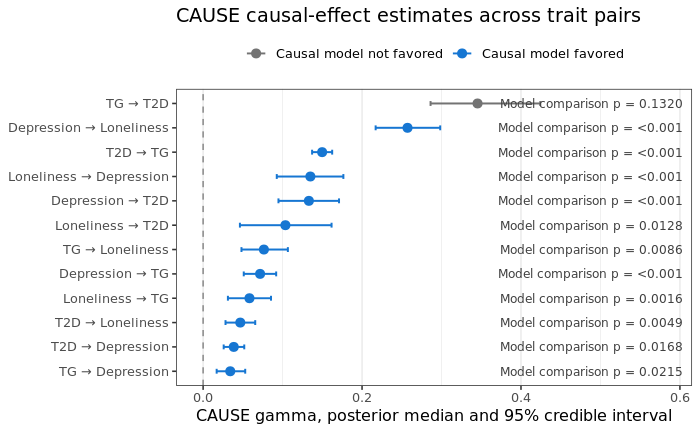

- evidence that triglycerides and T2D share liability via horizontal pleiotropy, but there is some evidence of T2D on triglycerides, independently of pleiotropic effects

#### T2D to Depression

#### Format Dep to Triglycerides